# Credit Card Fraud Detection.

# Content

- Introduction
- Importing Libraries and Modules
- Read the Data
- Check the data
  - Glimpse the data
  - Check missing data
  - Check data unbalance
- Exploratory Data Analysis (EDA)
  - Time-Based Transaction Analysis
  - Fraud vs Non-Fraud Transaction Analysis
  - Transaction Amount Distribution
- Feature Analysis
  - Features Correlations
  - Features Density Plots
- Predictive models
  - RandomForestClassifier
  - LogisticRegression
  - AdaBoostClassifier
- Cross Validation Strategy using LightGBM
- Conclusions
- References

### Section 1. Introduction

The datasets contains transactions made by credit cards in September 2013 by European cardholders. This dataset presents transactions that occurred in two days, where we have **492 frauds** out of **284,807 transactions**. The dataset is **highly unbalanced**, the **positive class (frauds)** account for **0.172%** of all transactions.

It contains only numerical input variables which are the result of a **PCA transformation**.

Due to confidentiality issues, there are not provided the original features and more background information about the data.

- Features **V1**, **V2**, ... **V28** are the **principal components** obtained with **PCA**;
- The only features which have not been transformed with PCA are **Time** and **Amount** . Feature Time contains the seconds elapsed between each transaction and the first transaction in the dataset. The feature Amount is the transaction Amount, this feature can be used for example-dependant cost-senstive learning.
- Feature **Class** is the response variable and it takes value **1** in case of fraud and **0** otherwise.

### Section 2. Importing Libraries and Modules

```python
import numpy as np
import pandas as pd
import seaborn as sns
import matplotlib.pyplot as plt
from datetime import datetime

from sklearn.ensemble import RandomForestClassifier
from sklearn.linear_model import LogisticRegression
from sklearn.ensemble import AdaBoostClassifier
from sklearn.model_selection import train_test_split
from sklearn.metrics import classification_report, confusion_matrix, roc_auc_score

import gc
from sklearn.model_selection import KFold
from sklearn import svm
import lightgbm as lgb
from lightgbm import LGBMClassifier

import warnings
warnings.filterwarnings('ignore')
```

### Section 3. Read the Data

```python
df=pd.read_csv(r"C:\Users\Dell\Desktop\9May-24July\16May Project-2\creditcard.csv")
df.head()
```

|  | Time | V1 | V2 | V3 | V4 | V5 | V6 | V7 | V8 | V9 | ... | V21 | V22 | V23 | V24 | V25 | V26 | V27 | V28 | Amount | Class |
| --- | --- | --- | --- | --- | --- | --- | --- | --- | --- | --- | --- | --- | --- | --- | --- | --- | --- | --- | --- | --- | --- |
| 0 | 0.0 | -1.359807 | -0.072781 | 2.536347 | 1.378155 | -0.338321 | 0.462388 | 0.239599 | 0.098698 | 0.363787 | ... | -0.018307 | 0.277838 | -0.110474 | 0.066928 | 0.128539 | -0.189115 | 0.133558 | -0.021053 | 149.62 | 0 |
| 1 | 0.0 | 1.191857 | 0.266151 | 0.166480 | 0.448154 | 0.060018 | -0.082361 | -0.078803 | 0.085102 | -0.255425 | ... | -0.225775 | -0.638672 | 0.101288 | -0.339846 | 0.167170 | 0.125895 | -0.008983 | 0.014724 | 2.69 | 0 |
| 2 | 1.0 | -1.358354 | -1.340163 | 1.773209 | 0.379780 | -0.503198 | 1.800499 | 0.791461 | 0.247676 | -1.514654 | ... | 0.247998 | 0.771679 | 0.909412 | -0.689281 | -0.327642 | -0.139097 | -0.055353 | -0.059752 | 378.66 | 0 |
| 3 | 1.0 | -0.966272 | -0.185226 | 1.792993 | -0.863291 | -0.010309 | 1.247203 | 0.237609 | 0.377436 | -1.387024 | ... | -0.108300 | 0.005274 | -0.190321 | -1.175575 | 0.647376 | -0.221929 | 0.062723 | 0.061458 | 123.50 | 0 |
| 4 | 2.0 | -1.158233 | 0.877737 | 1.548718 | 0.403034 | -0.407193 | 0.095921 | 0.592941 | -0.270533 | 0.817739 | ... | -0.009431 | 0.798278 | -0.137458 | 0.141267 | -0.206010 | 0.502292 | 0.219422 | 0.215153 | 69.99 | 0 |

5 rows × 31 columns

```python
print("Data Dimension: ",df.shape)
```

```
Data Dimension:  (284807, 31)
```

### Section 4. Check the Data

### 4.1 Data Overview

```python
df.describe()
```

|  | Time | V1 | V2 | V3 | V4 | V5 | V6 | V7 | V8 | V9 | ... | V21 | V22 | V23 | V24 | V25 | V26 | V27 | V28 | Amount | Class |
| --- | --- | --- | --- | --- | --- | --- | --- | --- | --- | --- | --- | --- | --- | --- | --- | --- | --- | --- | --- | --- | --- |
| count | 284807.000000 | 2.848070e+05 | 2.848070e+05 | 2.848070e+05 | 2.848070e+05 | 2.848070e+05 | 2.848070e+05 | 2.848070e+05 | 2.848070e+05 | 2.848070e+05 | ... | 2.848070e+05 | 2.848070e+05 | 2.848070e+05 | 2.848070e+05 | 2.848070e+05 | 2.848070e+05 | 2.848070e+05 | 2.848070e+05 | 284807.000000 | 284807.000000 |
| mean | 94813.859575 | 1.175161e-15 | 3.384974e-16 | -1.379537e-15 | 2.094852e-15 | 1.021879e-15 | 1.494498e-15 | -5.620335e-16 | 1.149614e-16 | -2.414189e-15 | ... | 1.628620e-16 | -3.576577e-16 | 2.618565e-16 | 4.473914e-15 | 5.109395e-16 | 1.686100e-15 | -3.661401e-16 | -1.227452e-16 | 88.349619 | 0.001727 |
| std | 47488.145955 | 1.958696e+00 | 1.651309e+00 | 1.516255e+00 | 1.415869e+00 | 1.380247e+00 | 1.332271e+00 | 1.237094e+00 | 1.194353e+00 | 1.098632e+00 | ... | 7.345240e-01 | 7.257016e-01 | 6.244603e-01 | 6.056471e-01 | 5.212781e-01 | 4.822270e-01 | 4.036325e-01 | 3.300833e-01 | 250.120109 | 0.041527 |
| min | 0.000000 | -5.640751e+01 | -7.271573e+01 | -4.832559e+01 | -5.683171e+00 | -1.137433e+02 | -2.616051e+01 | -4.355724e+01 | -7.321672e+01 | -1.343407e+01 | ... | -3.483038e+01 | -1.093314e+01 | -4.480774e+01 | -2.836627e+00 | -1.029540e+01 | -2.604551e+00 | -2.256568e+01 | -1.543008e+01 | 0.000000 | 0.000000 |
| 25% | 54201.500000 | -9.203734e-01 | -5.985499e-01 | -8.903648e-01 | -8.486401e-01 | -6.915971e-01 | -7.682956e-01 | -5.540759e-01 | -2.086297e-01 | -6.430976e-01 | ... | -2.283949e-01 | -5.423504e-01 | -1.618463e-01 | -3.545861e-01 | -3.171451e-01 | -3.269839e-01 | -7.083953e-02 | -5.295979e-02 | 5.600000 | 0.000000 |
| 50% | 84692.000000 | 1.810880e-02 | 6.548556e-02 | 1.798463e-01 | -1.984653e-02 | -5.433583e-02 | -2.741871e-01 | 4.010308e-02 | 2.235804e-02 | -5.142873e-02 | ... | -2.945017e-02 | 6.781943e-03 | -1.119293e-02 | 4.097606e-02 | 1.659350e-02 | -5.213911e-02 | 1.342146e-03 | 1.124383e-02 | 22.000000 | 0.000000 |
| 75% | 139320.500000 | 1.315642e+00 | 8.037239e-01 | 1.027196e+00 | 7.433413e-01 | 6.119264e-01 | 3.985649e-01 | 5.704361e-01 | 3.273459e-01 | 5.971390e-01 | ... | 1.863772e-01 | 5.285536e-01 | 1.476421e-01 | 4.395266e-01 | 3.507156e-01 | 2.409522e-01 | 9.104512e-02 | 7.827995e-02 | 77.165000 | 0.000000 |
| max | 172792.000000 | 2.454930e+00 | 2.205773e+01 | 9.382558e+00 | 1.687534e+01 | 3.480167e+01 | 7.330163e+01 | 1.205895e+02 | 2.000721e+01 | 1.559499e+01 | ... | 2.720284e+01 | 1.050309e+01 | 2.252841e+01 | 4.584549e+00 | 7.519589e+00 | 3.517346e+00 | 3.161220e+01 | 3.384781e+01 | 25691.160000 | 1.000000 |

8 rows × 31 columns

### 4.2 Checking Missing Values, if any

```python
total=df.isnull().sum().sort_values(ascending = False)
percent = (df.isnull().sum()/df.isnull().count()*100).sort_values(ascending = False)
pd.concat([total, percent], axis=1, keys=['Total', 'Percent']).transpose()
```

|  | Time | V1 | V2 | V3 | V4 | V5 | V6 | V7 | V8 | V9 | ... | V21 | V22 | V23 | V24 | V25 | V26 | V27 | V28 | Amount | Class |
| --- | --- | --- | --- | --- | --- | --- | --- | --- | --- | --- | --- | --- | --- | --- | --- | --- | --- | --- | --- | --- | --- |
| Total | 0.0 | 0.0 | 0.0 | 0.0 | 0.0 | 0.0 | 0.0 | 0.0 | 0.0 | 0.0 | ... | 0.0 | 0.0 | 0.0 | 0.0 | 0.0 | 0.0 | 0.0 | 0.0 | 0.0 | 0.0 |
| Percent | 0.0 | 0.0 | 0.0 | 0.0 | 0.0 | 0.0 | 0.0 | 0.0 | 0.0 | 0.0 | ... | 0.0 | 0.0 | 0.0 | 0.0 | 0.0 | 0.0 | 0.0 | 0.0 | 0.0 | 0.0 |

2 rows × 31 columns

### 4.3 Checking Data Unbalance

```
   Class  values
0      0  284315
1      1     492
```

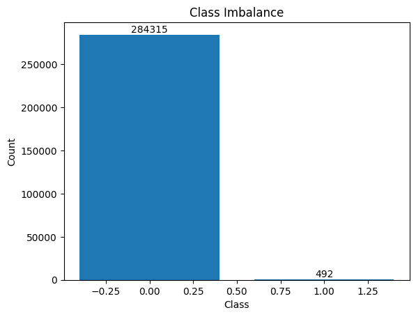

```python
temp = df["Class"].value_counts()
plot_df = pd.DataFrame({
    'Class': temp.index,
    'values': temp.values
})
print(plot_df)

bars = plt.bar(temp.index, temp.values)
for bar in bars:
    y = bar.get_height()
    plt.text(bar.get_x() + bar.get_width()/2,y,int(y),ha='center',va='bottom')

plt.title("Class Imbalance")
plt.xlabel("Class")
plt.ylabel("Count")
plt.show()
```

## Section 5. Data Exploration

### 5.1 Transactions in time

Plotting a Kernel Density Estimation (KDE) for fraud and non-fraud Transaction in time

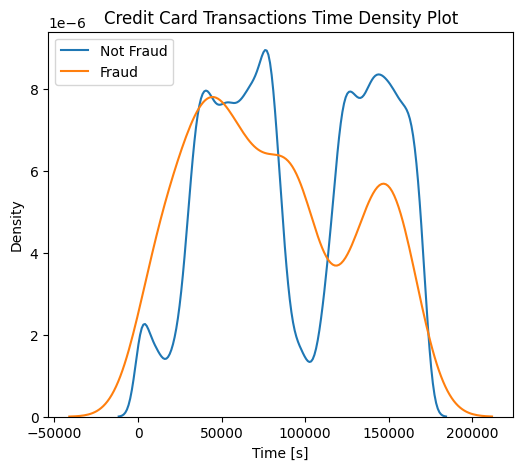

```python
class_0 = df[df['Class'] == 0]['Time']   # stores transaction times for non-fraud transactions.
class_1 = df[df['Class'] == 1]['Time']   # stores transaction times for fraud transactions.

plt.figure(figsize=(6,5))

sns.kdeplot(class_0, label='Not Fraud')
sns.kdeplot(class_1, label='Fraud')

plt.title('Credit Card Transactions Time Density Plot')
plt.xlabel('Time [s]')
plt.ylabel('Density')

plt.legend()
plt.show()
```

Fraudulent transactions have a distribution more even than valid transactions - are equaly distributed in time, including the low real transaction times, during night in Europe timezone.

Let's look into more details to the time distribution of both classes transaction, as well as to aggregated values of transaction count and amount, per hour. We assume (based on observation of the time distribution of transactions) that the time unit is second.

*Time-based transaction analysis*

```python
df['Hour'] = df['Time'].apply(lambda x: np.floor(x / 3600))

tmp = df.groupby(['Hour', 'Class'])['Amount'].aggregate(['min', 'max', 'count', 'sum', 'mean', 'median', 'var']).reset_index()
temp_df = pd.DataFrame(tmp)
temp_df.columns = ['Hour', 'Class', 'Min', 'Max', 'Transactions', 'Sum', 'Mean', 'Median', 'Var']
temp_df.head()
```

|  | Hour | Class | Min | Max | Transactions | Sum | Mean | Median | Var |
| --- | --- | --- | --- | --- | --- | --- | --- | --- | --- |
| 0 | 0.0 | 0 | 0.0 | 7712.43 | 3961 | 256572.87 | 64.774772 | 12.990 | 45615.821201 |
| 1 | 0.0 | 1 | 0.0 | 529.00 | 2 | 529.00 | 264.500000 | 264.500 | 139920.500000 |
| 2 | 1.0 | 0 | 0.0 | 1769.69 | 2215 | 145806.76 | 65.826980 | 22.820 | 20053.615770 |
| 3 | 1.0 | 1 | 59.0 | 239.93 | 2 | 298.93 | 149.465000 | 149.465 | 16367.832450 |
| 4 | 2.0 | 0 | 0.0 | 4002.88 | 1555 | 106989.39 | 68.803466 | 17.900 | 45355.430437 |

### 5.2 Aggregate Amount per Hour

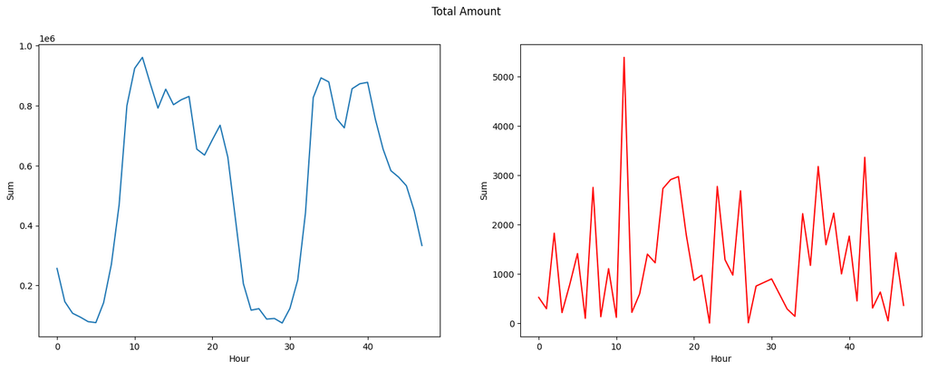

```python
fig, (ax1, ax2) = plt.subplots(ncols=2, figsize=(18,6))
s = sns.lineplot(ax = ax1, x="Hour", y="Sum", data=temp_df.loc[temp_df.Class==0])
s = sns.lineplot(ax = ax2, x="Hour", y="Sum", data=temp_df.loc[temp_df.Class==1], color="red")
plt.suptitle("Total Amount")
plt.show();
```

### 5.3 Total No. of Transactions per Hour

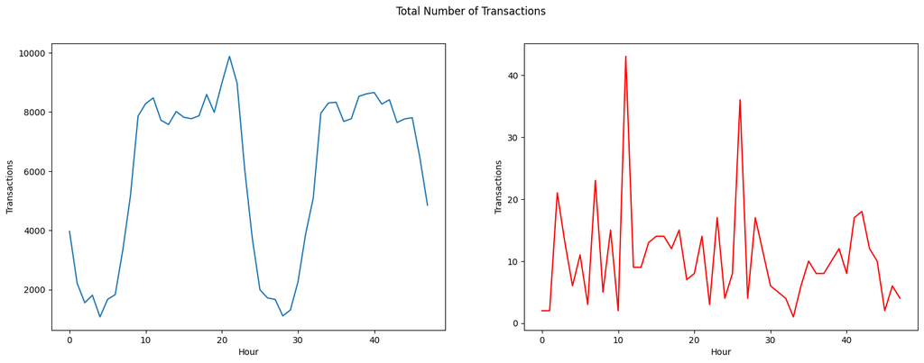

```python
fig, (ax1, ax2) = plt.subplots(ncols=2, figsize=(18,6))
s = sns.lineplot(ax = ax1, x="Hour", y="Transactions", data=temp_df.loc[temp_df.Class==0])
s = sns.lineplot(ax = ax2, x="Hour", y="Transactions", data=temp_df.loc[temp_df.Class==1], color="red")
plt.suptitle("Total Number of Transactions")
plt.show();
```

### 5.4 Average Amount of Transactions per Hour

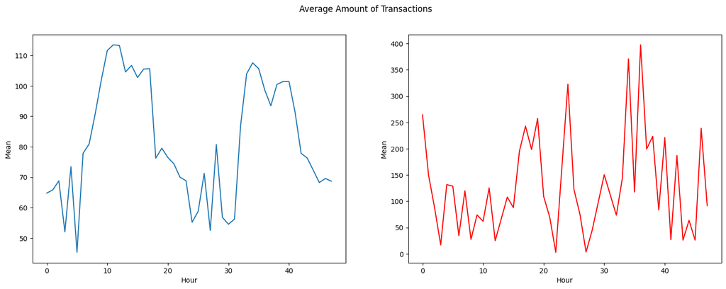

```python
fig, (ax1, ax2) = plt.subplots(ncols=2, figsize=(18,6))
s = sns.lineplot(ax = ax1, x="Hour", y="Mean", data=temp_df.loc[temp_df.Class==0])
s = sns.lineplot(ax = ax2, x="Hour", y="Mean", data=temp_df.loc[temp_df.Class==1], color="red")
plt.suptitle("Average Amount of Transactions")
plt.show();
```

### 5.5 Maximum Amount of Transactions per Hour

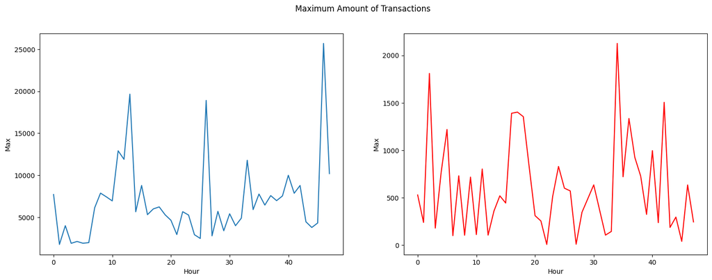

```python
fig, (ax1, ax2) = plt.subplots(ncols=2, figsize=(18,6))
s = sns.lineplot(ax = ax1, x="Hour", y="Max", data=temp_df.loc[temp_df.Class==0])
s = sns.lineplot(ax = ax2, x="Hour", y="Max", data=temp_df.loc[temp_df.Class==1], color="red")
plt.suptitle("Maximum Amount of Transactions")
plt.show();
```

### 5.6 Minimum Amount of Transactions per Hour

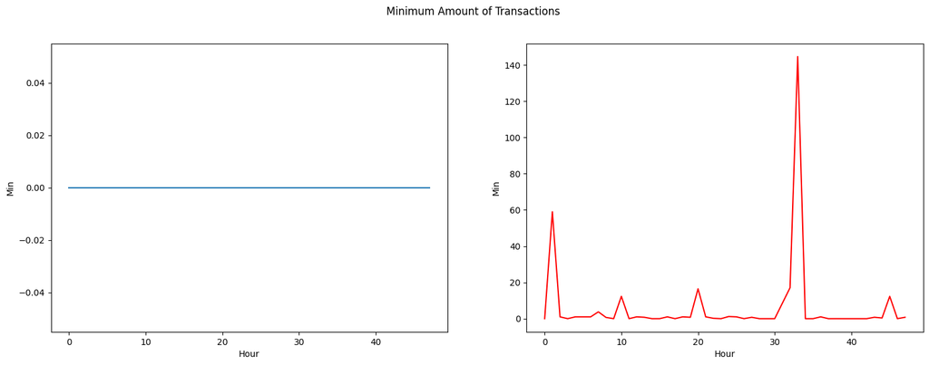

```python
fig, (ax1, ax2) = plt.subplots(ncols=2, figsize=(18,6))
s = sns.lineplot(ax = ax1, x="Hour", y="Min", data=temp_df.loc[temp_df.Class==0])
s = sns.lineplot(ax = ax2, x="Hour", y="Min", data=temp_df.loc[temp_df.Class==1], color="red")
plt.suptitle("Minimum Amount of Transactions")
plt.show();
```

### 5.7 Transactions amount

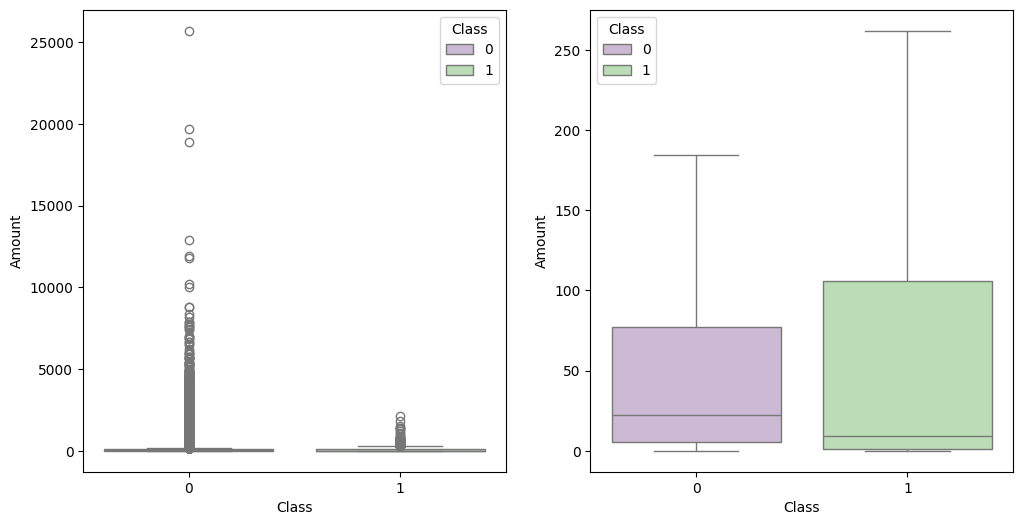

```python
fig, (ax1, ax2) = plt.subplots(ncols=2, figsize=(12,6))
s = sns.boxplot(ax = ax1, x="Class", y="Amount", hue="Class",data=df, palette="PRGn",showfliers=True)
s = sns.boxplot(ax = ax2, x="Class", y="Amount", hue="Class",data=df, palette="PRGn",showfliers=False)
plt.show();
```

Fraudulent transactions do not necessarily have the highest amounts. Many frauds occur at smaller or moderate transaction values.

Meanwhile, normal transactions contain many very large purchases, creating many outliers.

```python
tmp = df[['Amount','Class']].copy()
class_0 = tmp.loc[tmp['Class'] == 0]['Amount']
class_1 = tmp.loc[tmp['Class'] == 1]['Amount']
class_0.describe()
```

```
count    284315.000000
mean         88.291022
std         250.105092
min           0.000000
25%           5.650000
50%          22.000000
75%          77.050000
max       25691.160000
Name: Amount, dtype: float64
```

```python
class_1.describe()
```

```
count     492.000000
mean      122.211321
std       256.683288
min         0.000000
25%         1.000000
50%         9.250000
75%       105.890000
max      2125.870000
Name: Amount, dtype: float64
```

Let's **plot the fraudulent transactions (amount) against time**. The time is shown is seconds from the start of the time period (totaly 48h, over 2 days).

### 5.8 Fraudulent transactions (amount) against time Plot

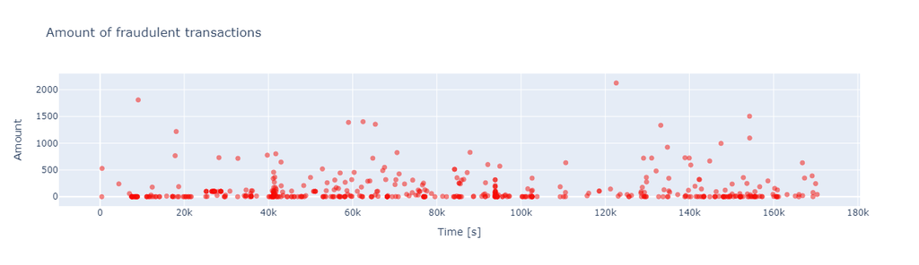

```python
import plotly.graph_objs as go
from plotly.offline import iplot

fraud = df.loc[df['Class'] == 1]

trace = go.Scatter(
    x = fraud['Time'],y = fraud['Amount'],
    name="Amount",
     marker=dict(color='rgb(238,23,11)',line=dict(color='red',width=1),opacity=0.5,),
    text= fraud['Amount'],
    mode = "markers"
)
data = [trace]
layout = dict(title = 'Amount of fraudulent transactions',
          xaxis = dict(title = 'Time [s]', showticklabels=True),
          yaxis = dict(title = 'Amount'),
          hovermode='closest'
         )
fig = dict(data=data, layout=layout)
iplot(fig, filename='fraud-amount')
```

Fraudulent transactions occur throughout the entire time period rather than at a single specific time. Most fraud transactions involve relatively small amounts, concentrated near the bottom of the graph. A few transactions have very high amounts, appearing as clear outliers. Fraud activity is sparse and irregular, with no smooth or consistent pattern over time.

## Section 6. Feature Analysis

### 6.1 Features Correlation

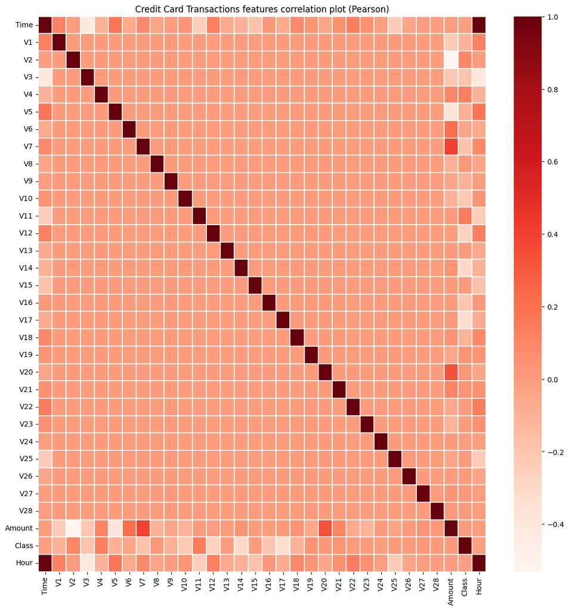

```python
plt.figure(figsize = (14,14))
plt.title('Credit Card Transactions features correlation plot (Pearson)')
corr = df.corr()
sns.heatmap(corr,xticklabels=corr.columns,yticklabels=corr.columns,linewidths=.1,cmap="Reds")
plt.show()
```

As expected, there is no notable correlation between features V1-V28. There are certain correlations between some of these features and Time (inverse correlation with V3) and Amount (direct correlation with V7 and V20, inverse correlation with V1 and V5).

Let's plot the correlated and inverse correlated values on the same graph.

Let's start with the direct correlated values: {V20;Amount} and {V7;Amount}.

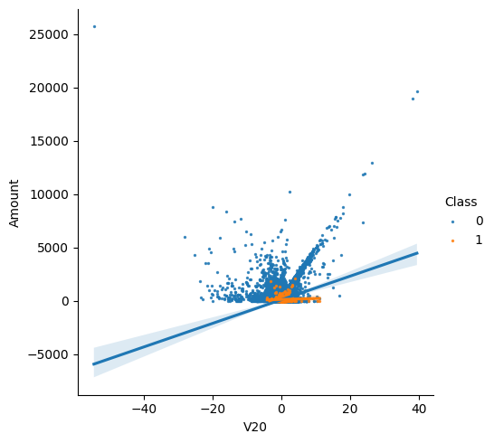

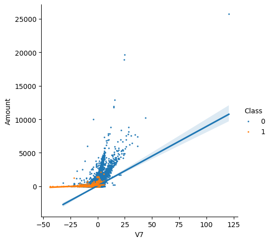

```python
s = sns.lmplot(x='V20', y='Amount',data=df, hue='Class', fit_reg=True,scatter_kws={'s':2})
s = sns.lmplot(x='V7', y='Amount',data=df, hue='Class', fit_reg=True,scatter_kws={'s':2})
plt.show()
```

We can confirm that the two couples of features are correlated (the regression lines for **Class = 0** have a positive slope, whilst the regression line for **Class = 1** have a smaller positive slope).

Let's plot now the inverse correlated values.

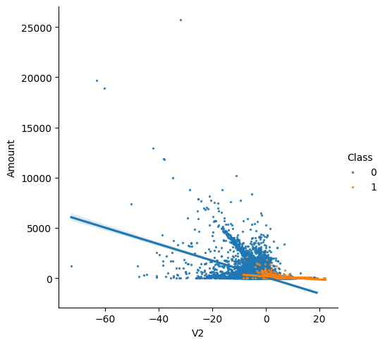

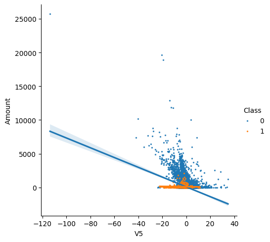

```python
s = sns.lmplot(x='V2', y='Amount',data=df, hue='Class', fit_reg=True,scatter_kws={'s':2})
s = sns.lmplot(x='V5', y='Amount',data=df, hue='Class', fit_reg=True,scatter_kws={'s':2})
plt.show()
```

We can confirm that the two couples of features are inverse correlated (the regression lines for **Class = 0** have a negative slope while the regression lines for **Class = 1** have a very small negative slope).

### 6.2 Features Density Plot

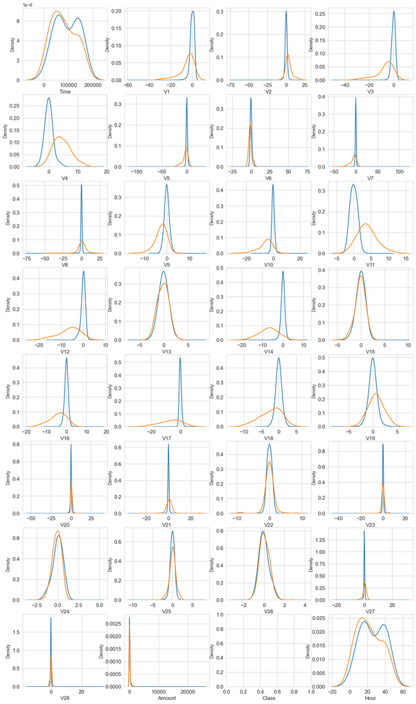

```python
var = df.columns.values

i = 0
t0 = df.loc[df['Class'] == 0]
t1 = df.loc[df['Class'] == 1]

sns.set_style('whitegrid')
plt.figure()
fig, ax = plt.subplots(8,4,figsize=(16,28))

for feature in var:
    i += 1
    plt.subplot(8,4,i)
    sns.kdeplot(t0[feature], bw=0.5,label="Class = 0")
    sns.kdeplot(t1[feature], bw=0.5,label="Class = 1")
    plt.xlabel(feature, fontsize=12)
    locs, labels = plt.xticks()
    plt.tick_params(axis='both', which='major', labelsize=12)
plt.show();
```

For some of the features we can observe a good selectivity in terms of distribution for the two values of **Class**: **V4**, **V11** have clearly separated distributions for **Class** values 0 and 1, **V12**, **V14**, **V18** are partially separated, **V1**, **V2**, **V3**, **V10** have a quite distinct profile, whilst **V25**, **V26**, **V28** have similar profiles for the two values of **Class**.

In general, with just few exceptions (**Time** and **Amount**), the features distribution for legitimate transactions (values of **Class = 0**) is centered around 0, sometime with a long queue at one of the extremities. In the same time, the fraudulent transactions (values of **Class = 1**) have a skewed (asymmetric) distribution.

# Section 7. Predictive Models

Let's define the predictor features and the target features.In our case, there are no categorical feature.

```python
target = 'Class'
predictors = ['Time', 'V1', 'V2', 'V3', 'V4', 'V5', 'V6', 'V7', 'V8', 'V9', 'V10',\
       'V11', 'V12', 'V13', 'V14', 'V15', 'V16', 'V17', 'V18', 'V19',\
       'V20', 'V21', 'V22', 'V23', 'V24', 'V25', 'V26', 'V27', 'V28',\
       'Amount']
```

Let's define train, validation and test sets:-

📘 Training Set: Used to train the machine learning model using labeled data.

📗 Validation Set: Used to tune hyperparameters and improve model performance.

📕 Test Set: Used to evaluate the final model on unseen data.

```python
from sklearn.model_selection import train_test_split
train_df, test_df =train_test_split(df,
                                    test_size=0.20, random_state=2018,
                                    shuffle=True )
train_df, valid_df =train_test_split(train_df,
                                    test_size=0.20, random_state=2018,
                                    shuffle=True )
```

## 7.1 RandomForestClassifier

**Define model parameters**

Let's set the parameters for the model.

We will use as validation criterion **GINI**, which formula is GINI = 2*(AUC) - 1, where AUC is the Receiver Operating Characteristic - Area Under Curve (ROC-AUC).Number of estimators is set to **100** and number of parallel jobs is set to **4**.

We start by initializing the RandomForestClassifier.

```python
from sklearn.ensemble import RandomForestClassifier
clf = RandomForestClassifier(n_jobs=4, random_state=2018, criterion='gini', n_estimators=100, verbose=False)
```

```python
clf.fit(train_df[predictors], train_df[target].values)
```

```
RandomForestClassifier(n_jobs=4, random_state=2018, verbose=False)
```

Let's now predict the target values for the valid_df data, using predict function.

```python
preds = clf.predict(valid_df[predictors])
print(pd.Series(preds).value_counts())
```

```
0    45490
1       79
Name: count, dtype: int64
```

**Classification Report**

- **Precision** → Percentage of predicted positive samples that are actually positive.
- **Recall** → Percentage of actual positive samples correctly identified by the model.
- **F1-score** → Harmonic mean of precision and recall, balancing both metrics.
- **Support** → Total number of actual samples present in each class.
- **Accuracy** → Percentage of total predictions correctly classified by the model.
- **Macro Average** → Average of metrics calculated equally across all classes without considering class imbalance.
- **Weighted Average** → Average of metrics weighted according to the number of samples in each class.

```python
preds_proba = clf.predict_proba(valid_df[predictors])[:, 1]
print("\nClassification Report:")
print(classification_report(valid_df[target].values, preds))
```

```
Classification Report:
              precision    recall  f1-score   support

           0       1.00      1.00      1.00     45467
           1       0.91      0.71      0.80       102

    accuracy                           1.00     45569
   macro avg       0.96      0.85      0.90     45569
weighted avg       1.00      1.00      1.00     45569
```

**Feature Importance**

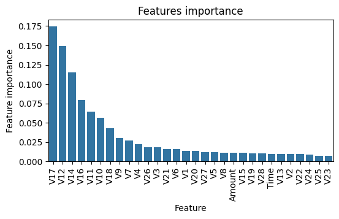

```python
tmp = pd.DataFrame({'Feature': predictors, 'Feature importance': clf.feature_importances_})
tmp = tmp.sort_values(by='Feature importance',ascending=False)

plt.figure(figsize = (6,3))
plt.title('Features importance')

s = sns.barplot(x='Feature',y='Feature importance',data=tmp)
s.set_xticklabels(s.get_xticklabels(),rotation=90)

plt.show()
```

**Confusion Matrix**

Confusion matrix is evaluation tool used in classification problems that summarizes the number of correct and incorrect predictions made by a model. It contains True Positives (TP), True Negatives (TN), False Positives (FP), and False Negatives (FN)

Confusion matrix for the results we obtained

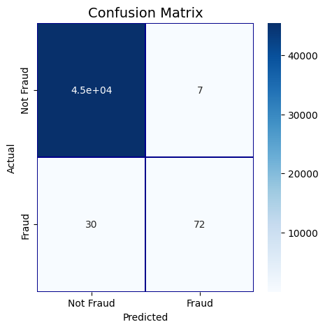

```python
cm = pd.crosstab(valid_df[target].values, preds, rownames=['Actual'], colnames=['Predicted'])
fig, (ax1) = plt.subplots(ncols=1, figsize=(4,4))

sns.heatmap(cm,
            xticklabels=['Not Fraud', 'Fraud'],
            yticklabels=['Not Fraud', 'Fraud'],
            annot=True,ax=ax1,
            linewidths=.2,linecolor="Darkblue", cmap="Blues")

plt.title('Confusion Matrix', fontsize=12)
plt.show()
```

Confussion matrix are not a very good tool to represent the results in the case of largely unbalanced data

ROC-AUC score is commonly used as a better evaluation metric for imbalanced datasets. It measures the ability of the model to distinguish between classes by considering both the True Positive Rate (sensitivity) and the False Positive Rate (related to Type I error). A higher ROC-AUC score indicates better classification performance with fewer Type I and Type II errors.

```python
from sklearn.metrics import roc_auc_score
roc_auc_score(valid_df[target].values, preds)
```

```
0.8528641975628091
```

The ROC-AUC score obtained with RandomForrestClassifier is **0.85**.

**Precision-Recall Curve**

The Precision-Recall Curve defines the relationship between:

Precision → how accurate your fraud predictions are

Recall → how many actual frauds your model successfully catches

as the classification threshold changes.

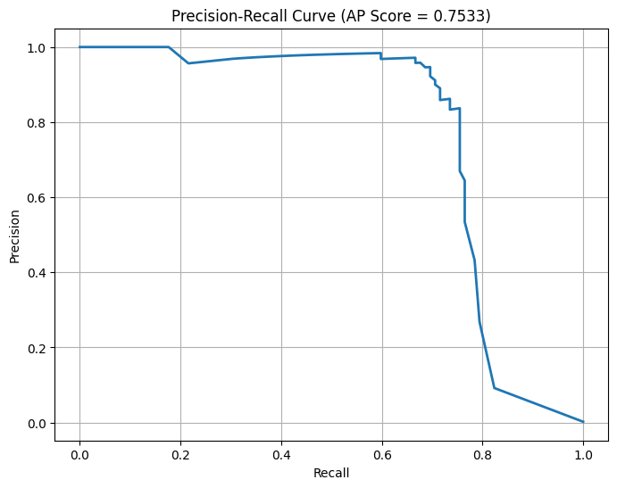

```python
from sklearn.metrics import precision_recall_curve
from sklearn.metrics import average_precision_score

precision, recall, thresholds = precision_recall_curve(
    valid_df[target].values,
    preds_proba
)

ap_score = average_precision_score(
    valid_df[target].values,
    preds_proba
)

plt.figure(figsize=(8,6))
plt.plot(recall, precision, linewidth=2)
plt.xlabel("Recall")
plt.ylabel("Precision")
plt.title(f"Precision-Recall Curve (AP Score = {ap_score:.4f})")
plt.grid(True)
plt.show()
```

Average Precision Score for RandomForestClassifier is **0.753**

## 7.2 Logistic Regression

Logistic Reg. predicts the probability of a data point belonging to a class by using a linear combination of features and applying the sigmoid function.

**Model Parameters**

- **Penalty** → Type of regularization (`l1`, `l2`, `elasticnet`)
- **C** → Inverse of regularization strength
- **Smaller C** → Stronger regularization
- **Solver** → Optimization algorithm (`lbfgs`, `liblinear`, `saga`)
- **max_iter** → Maximum training iterations
- **random_state** → Controls reproducibility
- **fit_intercept** → Adds intercept term (`True/False`)
- **class_weight** → Handles imbalanced data (`balanced`)

**Classification Report, ROC-AUC Score**

```python
from sklearn.linear_model import LogisticRegression
from sklearn.model_selection import train_test_split
from sklearn.metrics import classification_report, confusion_matrix, roc_auc_score
X = df[predictors]
y = df[target]

X_train, X_test, y_train, y_test = train_test_split(
    X, y,
    test_size=0.2,
    random_state=2018,
    stratify=y
)

model = LogisticRegression(
    max_iter=1000,
    class_weight='balanced',
    random_state=2018
)
model.fit(X_train, y_train)

y_pred = model.predict(X_test)
y_prob = model.predict_proba(X_test)[:, 1]

print("\nClassificioatn Report:")
print(classification_report(y_test, y_pred))

print("\nROC-AUC Score:")
print(roc_auc_score(y_test, y_prob))
```

```
Classificioatn Report:
              precision    recall  f1-score   support

           0       1.00      0.97      0.99     56864
           1       0.05      0.91      0.10        98

    accuracy                           0.97     56962
   macro avg       0.53      0.94      0.54     56962
weighted avg       1.00      0.97      0.98     56962


ROC-AUC Score:
0.9794506118429365
```

The ROC-AUC score obtained with LogisticRegressionClassifier is **0.98**.

**Confusion Matrix**

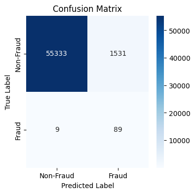

```python
import matplotlib.pyplot as plt
import seaborn as sns
from sklearn.metrics import confusion_matrix

cm = confusion_matrix(y_test, y_pred)
plt.figure(figsize=(4,4))
sns.heatmap(cm,
            annot=True,
            fmt='d',
            cmap='Blues',
            xticklabels=['Non-Fraud', 'Fraud'],
            yticklabels=['Non-Fraud', 'Fraud'])

plt.xlabel("Predicted Label")
plt.ylabel("True Label")
plt.title("Confusion Matrix")

plt.show()
```

**Feature Importance**

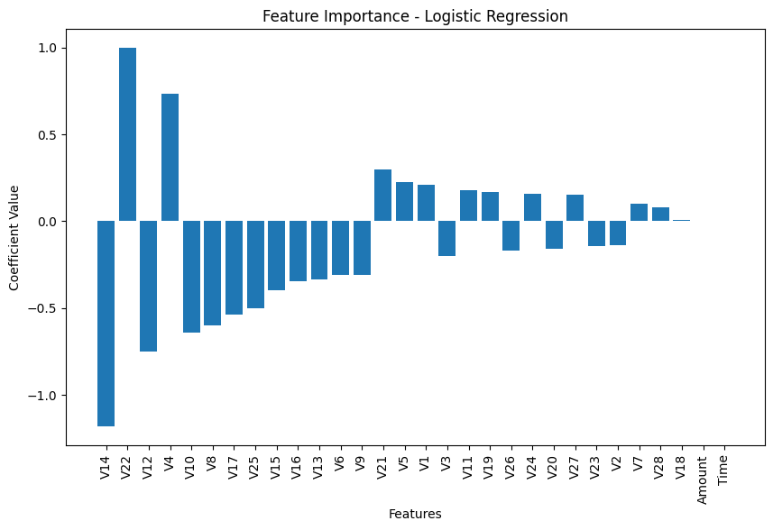

```python
import pandas as pd
import matplotlib.pyplot as plt

importance = pd.DataFrame({
    'Feature': X.columns,
    'Coefficient': model.coef_[0]
})
importance = importance.sort_values(by='Coefficient', key=abs, ascending=False)

plt.figure(figsize=(10,6))
plt.bar(importance['Feature'], importance['Coefficient'])

plt.xticks(rotation=90)
plt.xlabel("Features")
plt.ylabel("Coefficient Value")
plt.title("Feature Importance - Logistic Regression")

plt.show()
```

The most important feautres are **V14**, **V22**, **V12**, **V4**, **V10**, **V8**

**Precision-Recall Curve**

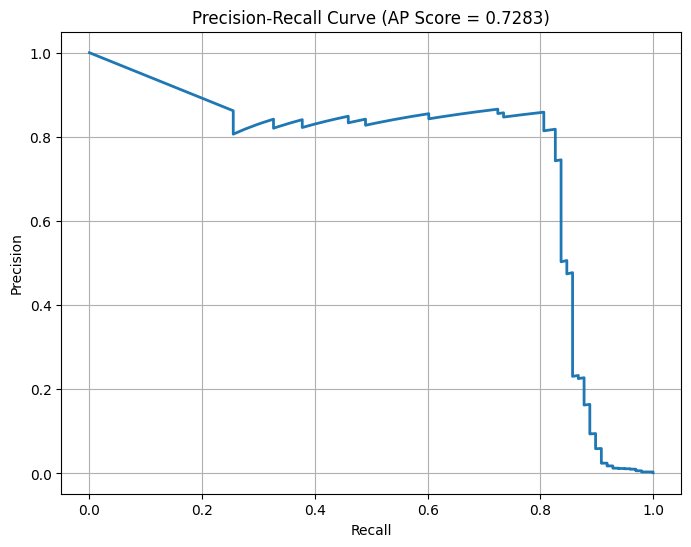

```python
precision, recall, thresholds = precision_recall_curve(
    y_test,
    y_prob
)

ap_score = average_precision_score(
    y_test,
    y_prob
)

plt.figure(figsize=(8,6))
plt.plot(recall, precision, linewidth=2)
plt.xlabel("Recall")
plt.ylabel("Precision")
plt.title(f"Precision-Recall Curve (AP Score = {ap_score:.4f})")
plt.grid(True)
plt.show()
```

Average Precision Score for Logistic Regression Classifier is **0.728**

## 7.3 AdaBoostClassifier

AdaBoost uses multiple weak learners, usually shallow decision trees, and combines them sequentially to build a strong classifier. It works by assigning higher weights to previously misclassified samples so that each new learner focuses more on correcting earlier errors.

**Model Parameter**

- **n_estimators** → Number of weak learners/trees
- **learning_rate** → Contribution of each learner
- **random_state** → Controls reproducibility
- **estimator** → Base model used (default: decision tree stump)
- **algorithm** → Boosting algorithm

**Classification Report**

```python
from sklearn.ensemble import AdaBoostClassifier
clf = AdaBoostClassifier(
    random_state=2018,
    learning_rate=0.8,
    n_estimators=100
)
clf.fit(train_df[predictors], train_df[target].values)
preds = clf.predict(valid_df[predictors])

preds_proba = clf.predict_proba(valid_df[predictors])[:, 1]
print("\nClassification Report:")
print(classification_report(valid_df[target].values, preds))
```

```
Classification Report:
              precision    recall  f1-score   support

           0       1.00      1.00      1.00     45467
           1       0.77      0.63      0.69       102

    accuracy                           1.00     45569
   macro avg       0.89      0.81      0.85     45569
weighted avg       1.00      1.00      1.00     45569
```

**Feature Importance**

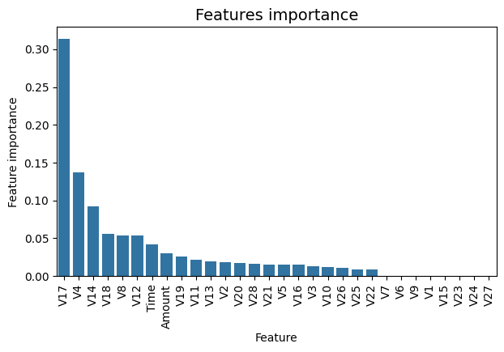

```python
tmp = pd.DataFrame({'Feature': predictors, 'Feature importance': clf.feature_importances_})
tmp = tmp.sort_values(by='Feature importance',ascending=False)
plt.figure(figsize = (7,4))
plt.title('Features importance',fontsize=14)
s = sns.barplot(x='Feature',y='Feature importance',data=tmp)
s.set_xticklabels(s.get_xticklabels(),rotation=90)
plt.show()
```

The most important features are **V17**, **V4**, **V14**, **V18**, **V8**, **V12**.

**Confusion Matrix**

Let's Visualize the Confusion Matrix

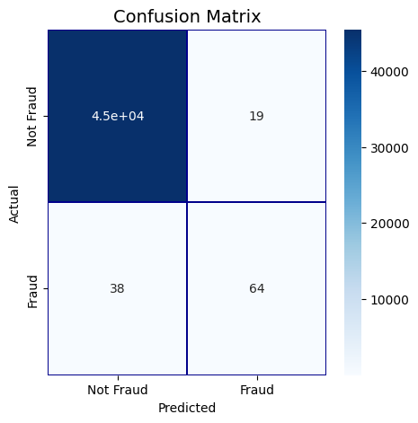

```python
cm = pd.crosstab(valid_df[target].values, preds,
                 rownames=['Actual'], colnames=['Predicted'])
fig, (ax1) = plt.subplots(ncols=1, figsize=(5,5))
sns.heatmap(cm,
            xticklabels=['Not Fraud', 'Fraud'],
            yticklabels=['Not Fraud', 'Fraud'],
            annot=True,ax=ax1,
            linewidths=.2,linecolor="Darkblue", cmap="Blues")
plt.title('Confusion Matrix', fontsize=14)
plt.show()
```

**ROC-AUC Score**

```python
roc_auc_score(valid_df[target].values, preds)
```

```
0.8135165474463918
```

The ROC-AUC score obtained with AdaBoostClassifier is **0.81**.

**Precision-Recall Curve**

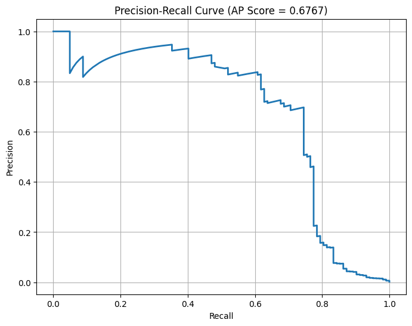

```python
precision, recall, thresholds = precision_recall_curve(
    valid_df[target].values,
    preds_proba
)

ap_score = average_precision_score(
    valid_df[target].values,
    preds_proba
)

plt.figure(figsize=(8,6))
plt.plot(recall, precision, linewidth=2)
plt.xlabel("Recall")
plt.ylabel("Precision")
plt.title(f"Precision-Recall Curve (AP Score = {ap_score:.4f})")
plt.grid(True)
plt.show()
```

Average Precision Score for AdaBoostClassifier is **0.677**

# Section 8. CrossValidation

Training and validation using cross-validation

Let's use now cross-validation. We will use cross-validation (KFolds) with 5 folds. Data is divided in 5 folds and, by rotation, we are training using 4 folds (n-1) and validate using the 5th (nth) fold.

### 8.1 Model Parameter

```python
from sklearn.model_selection import KFold
from sklearn.metrics import roc_auc_score
from lightgbm import LGBMClassifier
import lightgbm as lgb
import pandas as pd
import numpy as np
import gc

NUMBER_KFOLDS = 5
RANDOM_STATE = 2018
EARLY_STOP = 50
VERBOSE_EVAL = 50

kf = KFold(
    n_splits=NUMBER_KFOLDS,
    random_state=RANDOM_STATE,
    shuffle=True
)

oof_preds = np.zeros(train_df.shape[0])
test_preds = np.zeros(test_df.shape[0])

feature_importance_df = pd.DataFrame()
n_fold = 0
```

### 8.2 Training of model

```
Training until validation scores don't improve for 50 rounds
Early stopping, best iteration is:
[231]	valid_0's auc: 0.998184

Fold 1

Classification Report:
              precision    recall  f1-score   support

           0       1.00      1.00      1.00     36399
           1       0.00      0.00      0.00        57

    accuracy                           1.00     36456
   macro avg       0.50      0.50      0.50     36456
weighted avg       1.00      1.00      1.00     36456

AUC Score : 0.998184
AP Score  : 0.768323
Best Iteration : 231
```

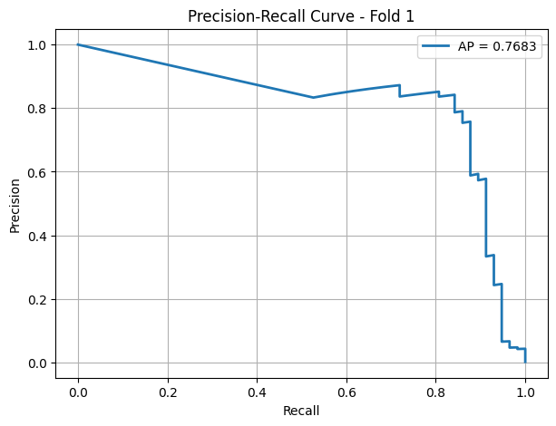

```
Training until validation scores don't improve for 50 rounds
Early stopping, best iteration is:
[44]	valid_0's auc: 0.966302

Fold 2

Classification Report:
              precision    recall  f1-score   support

           0       1.00      1.00      1.00     36378
           1       0.00      0.00      0.00        77

    accuracy                           1.00     36455
   macro avg       0.50      0.50      0.50     36455
weighted avg       1.00      1.00      1.00     36455

AUC Score : 0.966302
AP Score  : 0.672523
Best Iteration : 44
```

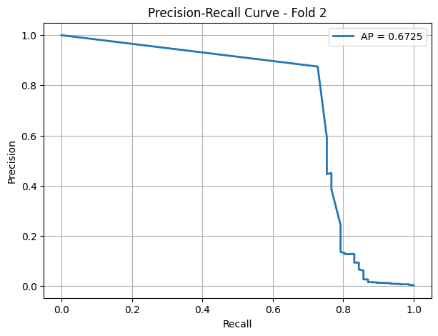

```
Training until validation scores don't improve for 50 rounds
Early stopping, best iteration is:
[202]	valid_0's auc: 0.943196

Fold 3

Classification Report:
              precision    recall  f1-score   support

           0       1.00      1.00      1.00     36404
           1       0.00      0.00      0.00        51

    accuracy                           1.00     36455
   macro avg       0.50      0.50      0.50     36455
weighted avg       1.00      1.00      1.00     36455

AUC Score : 0.943196
AP Score  : 0.742822
Best Iteration : 202
```

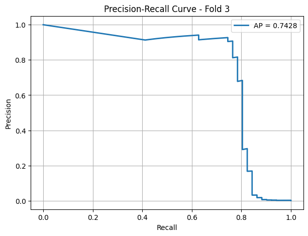

```
Training until validation scores don't improve for 50 rounds
Early stopping, best iteration is:
[69]	valid_0's auc: 0.993275

Fold 4

Classification Report:
              precision    recall  f1-score   support

           0       1.00      1.00      1.00     36408
           1       0.00      0.00      0.00        47

    accuracy                           1.00     36455
   macro avg       0.50      0.50      0.50     36455
weighted avg       1.00      1.00      1.00     36455

AUC Score : 0.993275
AP Score  : 0.625605
Best Iteration : 69
```

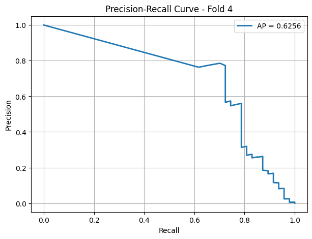

```
Training until validation scores don't improve for 50 rounds
Early stopping, best iteration is:
[126]	valid_0's auc: 0.984831

Fold 5

Classification Report:
              precision    recall  f1-score   support

           0       1.00      1.00      1.00     36397
           1       0.00      0.00      0.00        58

    accuracy                           1.00     36455
   macro avg       0.50      0.50      0.50     36455
weighted avg       1.00      1.00      1.00     36455

AUC Score : 0.984831
AP Score  : 0.766965
Best Iteration : 126
```

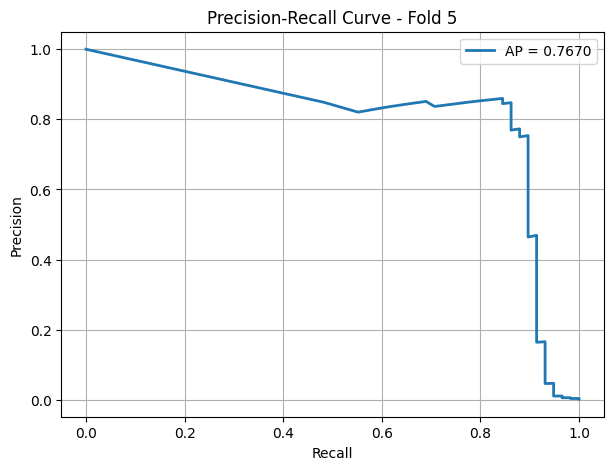

```
================ FINAL RESULTS ================
Full AUC Score : 0.970312
Full AP Score  : 0.511679
Mean Fold AUC  : 0.977158
Mean Fold AP   : 0.715248
```

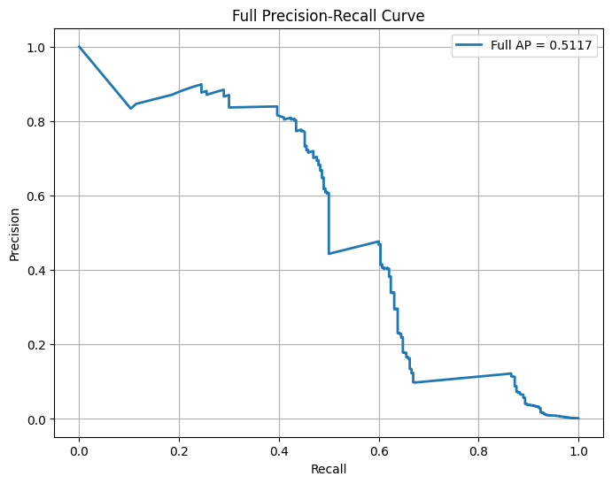

```python
ap_scores = []
auc_scores = []

n_fold = 0

for train_idx, valid_idx in kf.split(train_df):

    train_x = train_df[predictors].iloc[train_idx]
    train_y = train_df[target].iloc[train_idx]

    valid_x = train_df[predictors].iloc[valid_idx]
    valid_y = train_df[target].iloc[valid_idx]

    model = LGBMClassifier(
        nthread=-1,
        n_estimators=2000,
        learning_rate=0.01,
        num_leaves=80,
        colsample_bytree=0.98,
        subsample=0.78,
        reg_alpha=0.04,
        reg_lambda=0.073,
        subsample_for_bin=50,
        boosting_type='gbdt',
        is_unbalance=False,
        min_split_gain=0.025,
        min_child_weight=40,
        min_child_samples=510,
        objective='binary',
        metric='auc',
        verbose=-1
    )

    model.fit(
        train_x,
        train_y,
        eval_set=[(valid_x, valid_y)],
        eval_metric='auc',
        callbacks=[
            lgb.early_stopping(EARLY_STOP),
            lgb.log_evaluation(0)
        ]
    )

    oof_preds[valid_idx] = model.predict_proba(
        valid_x,
        num_iteration=model.best_iteration_
    )[:, 1]

    preds = (
        oof_preds[valid_idx] > 0.5
    ).astype(int)

    fold_importance_df = pd.DataFrame()

    fold_importance_df["feature"] = predictors
    fold_importance_df["importance"] = model.feature_importances_
    fold_importance_df["fold"] = n_fold + 1

    feature_importance_df = pd.concat(
        [feature_importance_df, fold_importance_df],
        axis=0
    )

    fold_auc = roc_auc_score(
        valid_y,
        oof_preds[valid_idx]
    )

    auc_scores.append(fold_auc)

    ap_score = average_precision_score(
        valid_y,
        oof_preds[valid_idx]
    )

    ap_scores.append(ap_score)

    print(f"\nFold {n_fold+1}")

    print("\nClassification Report:")
    print(classification_report(valid_y, preds))

    print(f"AUC Score : {fold_auc:.6f}")

    print(f"AP Score  : {ap_score:.6f}")

    print(f"Best Iteration : {model.best_iteration_}")

    precision, recall, thresholds = precision_recall_curve(
        valid_y,
        oof_preds[valid_idx]
    )

    plt.figure(figsize=(7,5))

    plt.plot(
        recall,
        precision,
        linewidth=2,
        label=f'AP = {ap_score:.4f}'
    )

    plt.xlabel("Recall")
    plt.ylabel("Precision")

    plt.title(
        f"Precision-Recall Curve - Fold {n_fold+1}"
    )

    plt.legend()

    plt.grid(True)

    plt.show()

    del model, train_x, train_y, valid_x, valid_y

    gc.collect()

    n_fold += 1

full_auc_score = roc_auc_score(
    train_df[target],
    oof_preds
)

full_ap_score = average_precision_score(
    train_df[target],
    oof_preds
)

print("\n================ FINAL RESULTS ================")

print(f"Full AUC Score : {full_auc_score:.6f}")

print(f"Full AP Score  : {full_ap_score:.6f}")

print(f"Mean Fold AUC  : {np.mean(auc_scores):.6f}")

print(f"Mean Fold AP   : {np.mean(ap_scores):.6f}")

precision, recall, thresholds = precision_recall_curve(
    train_df[target],
    oof_preds
)

plt.figure(figsize=(8,6))

plt.plot(
    recall,
    precision,
    linewidth=2,
    label=f'Full AP = {full_ap_score:.4f}'
)

plt.xlabel("Recall")
plt.ylabel("Precision")

plt.title("Full Precision-Recall Curve")

plt.legend()

plt.grid(True)

plt.show()
```

Full AUC Score : **0.970312**  
Full AP Score : **0.511679**  
Mean Fold AUC : **0.977158**  
Mean Fold AP : **0.715248**

### 8.3 Confusion Matrix

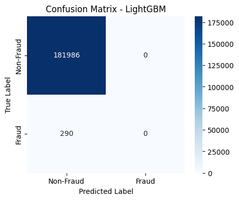

```python
import matplotlib.pyplot as plt
import seaborn as sns
from sklearn.metrics import confusion_matrix

preds = (oof_preds > 0.5).astype(int)

cm = confusion_matrix(train_df[target], preds)

plt.figure(figsize=(5,4))
sns.heatmap(
    cm,
    annot=True,
    fmt='d',
    cmap='Blues',
    xticklabels=['Non-Fraud', 'Fraud'],
    yticklabels=['Non-Fraud', 'Fraud']
)

plt.xlabel("Predicted Label")
plt.ylabel("True Label")
plt.title("Confusion Matrix - LightGBM")

plt.show()
```

### 8.4 Feauture Importance

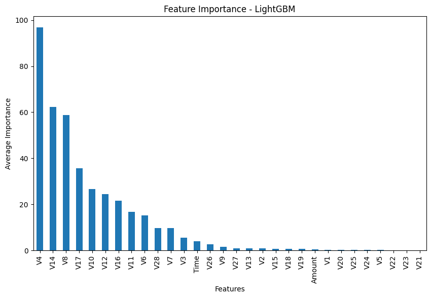

```python
importance = feature_importance_df.groupby(
    'feature'
)['importance'].mean().sort_values(ascending=False)

plt.figure(figsize=(10,6))

importance.plot(kind='bar')

plt.xlabel("Features")
plt.ylabel("Average Importance")
plt.title("Feature Importance - LightGBM")

plt.show()
```

The most important features are **V4**, **V14**, **V8**, **V17**.

# Section 9. Conclusions

We then followed with an **Logistic Regression** , with the AUC score **0.98** (HIGHEST) and Average Precision Score **0.728**

# Section 10. References

[1] Credit Card Fraud Detection Database — Anonymized credit card transactions labeled as fraudulent or genuine. Kaggle Dataset. https://www.kaggle.com/mlg-ulb/creditcardfraud

[2] Principal Component Analysis — Wikipedia Documentation. https://en.wikipedia.org/wiki/Principal_component_analysis

[3] RandomForestClassifier — Scikit-learn Documentation. http://scikit-learn.org/stable/modules/generated/sklearn.ensemble.RandomForestClassifier.html

[4] ROC-AUC Characteristic — Wikipedia Documentation. https://en.wikipedia.org/wiki/Receiver_operating_characteristic#Area_under_the_curve

[5] AdaBoostClassifier — Scikit-learn Documentation. http://scikit-learn.org/stable/modules/generated/sklearn.ensemble.AdaBoostClassifier.html

[6] LightGBM Python Implementation — GitHub Repository. https://github.com/Microsoft/LightGBM/tree/master/python-package

[7] LightGBM Algorithm Research Paper — Microsoft Research. https://www.microsoft.com/en-us/research/wp-content/uploads/2017/11/lightgbm.pdf

[8] Logistic Regression — Scikit-learn Documentation. https://scikit-learn.org/stable/modules/generated/sklearn.linear_model.LogisticRegression.html

[9] Precision-Recall Curve — Scikit-learn Documentation. https://scikit-learn.org/stable/modules/generated/sklearn.metrics.precision_recall_curve.html

[10] Average Precision Score — Scikit-learn Documentation. https://scikit-learn.org/stable/modules/generated/sklearn.metrics.average_precision_score.html

[11] Cross Validation — Scikit-learn Documentation. https://scikit-learn.org/stable/modules/cross_validation.html

[12] KFold Cross Validation — Scikit-learn Documentation. https://scikit-learn.org/stable/modules/generated/sklearn.model_selection.KFold.html